# Clustering con Python

**Joaquín Amat Rodrigo**

*Diciembre, 2020*

Más sobre ciencia de datos: [**cienciadedatos.net**](https://cienciadedatos.net)

- [PCA con Python](https://www.cienciadedatos.net/documentos/py19-pca-python.html)
- [Machine learning con Python y Scikit-learn](https://www.cienciadedatos.net/documentos/py06_machine_learning_python_scikitlearn.html)

## Introducción

El término *clustering* hace referencia a un amplio abanico de técnicas cuya finalidad es encontrar patrones o grupos (*clusters*) dentro de un conjunto de observaciones. Las particiones se establecen de forma que, las observaciones que están dentro de un mismo grupo, son similares entre ellas y distintas a las observaciones de otros grupos. Se trata de un método de aprendizaje no supervisado (*unsupervised*), ya que el proceso no tiene en cuenta a qué grupo pertenece realmente cada observación (si es que existe tal información). Esta característica es la que diferencia al *clustering* de las métodos de clasificación en el que sí emplea la verdadera clasificación durante su entrenamiento.

Dada la utilidad del *clustering* en disciplinas muy distintas (genómica, marketing...), se han desarrollado multitud de variantes y adaptaciones de sus métodos y algoritmos. Pueden diferenciarse tres grupos principales:

- *Partitioning Clustering*: este tipo de algoritmos requieren que el usuario especifique de antemano el número de *clusters* que se van a crear (*K-means*, *K-medoids*, *CLARA*).
- *Hierarchical Clustering*: este tipo de algoritmos no requieren que el usuario especifique de antemano el número de *clusters*. (*agglomerative clustering*, *divisive clustering*).
- Métodos que combinan o modifican los anteriores (*hierarchical K-means*, *fuzzy clustering*, *model based clustering* y *density based clustering*).

La librería [**Scikit Learn**](https://scikit-learn.org/stable/modules/clustering.html) contiene implementaciones en **Python** de los principales algoritmos de *clustering*.

## Medidas de distancia

Todos los métodos de *clustering* tienen una cosa en común, para llevar a cabo las agrupaciones necesitan definir y cuantificar la similitud entre las observaciones. El término distancia se emplea dentro del contexto del *clustering* como cuantificación de la similitud o diferencia entre observaciones. Si se representan las observaciones en un espacio $p$ dimensional, siendo $p$ el número de variables asociadas a cada observación, cuando más se asemejen dos observaciones más próximas estarán, de ahí que se emplee el término distancia. La característica que hace del *clustering* un método adaptable a escenarios muy diversos es que puede emplear casi cualquier tipo de distancia, lo que permite al investigador escoger la más adecuada para el estudio en cuestión. A continuación, se describen algunas de las más utilizadas.

### Distancia euclídea

La distancia euclídea entre dos puntos $p$ y $q$ se define como la longitud del segmento que une ambos puntos. En coordenadas cartesianas, la distancia euclídea se calcula empleando el teorema de Pitágoras. Por ejemplo, en un espacio de dos dimensiones en el que cada punto está definido por las coordenadas $(x,y)$, la distancia euclídea entre $p$ y $q$ es:

$$d_{euc}(p,q) = \sqrt{(p_x - q_x)^2 + (p_y - q_y)^2}$$

Esta ecuación puede generalizarse para un espacio euclídeo *n*-dimensional donde cada punto está definido por un vector de *n* coordenadas: $p = (p_1, p_2, p_3,...,p_n)$ y $q = (q_1, q_2, q_3,...,q_n)$.

$$d_{euc}(p,q) = \sqrt{(p_1 - q_1)^2 + (p_2 - q_2)^2 +...+(p_n - q_n)^2} =$$$$\sqrt{ \sum_{i=1}^n (p_i - q_i)^2}$$

Una forma de dar mayor peso a aquellas observaciones que están más alejadas es emplear la distancia euclídea al cuadrado. En el caso del *clustering*, donde se busca agrupar observaciones que minimicen la distancia, esto se traduce en una mayor influencia de aquellas observaciones que están más distantes.

### Distancia de Manhattan

La distancia de Manhattan, también conocida como *taxicab metric*, *rectilinear distance* o *L1 distance*, define la distancia entre dos puntos $p$ y $q$ como el sumatorio de las diferencias absolutas entre cada dimensión. Esta medida se ve menos afectada por *outliers* (es más robusta) que la distancia euclídea debido a que no eleva al cuadrado las diferencias.

$$d_{man}(p,q) = \sum_{i=1}^n |(p_i - q_i)|$$

La siguiente imagen muestra una comparación entre la distancia euclídea (segmento verde) y la distancia de manhattan (segmento rojo, amarillo y azul) en un espacio bidimensional. Existen múltiples caminos para unir dos puntos con una misma distancia de manhattan, pero solo uno con la distancia euclídea.

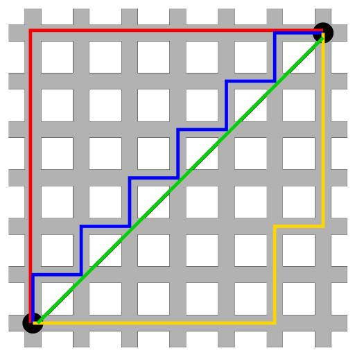

*Comparación distancia euclídea y manhattan en un espacio de dos dimensiones. Fuente; wikipedia*

### Correlación

La correlación es una medida de distancia muy útil cuando la definición de similitud se hace en términos de patrón o forma y no de desplazamiento o magnitud.

$$d_{cor}(p,q) = 1 - \text{correlacion}(p,q)$$

donde la correlación puede ser de distintos tipos (*Pearson*, *Spearman*, *Kendall*...)

En la siguiente imagen se muestra el perfil de 3 observaciones. *a* y *b* tienen exactamente el mismo patrón, pero *b* está desplazada 4 unidades por debajo de *a*. La observación *c* tiene un patrón distinto a las demás, pero su rango de valores es similar al de *b*. Acorde a la distancia euclídea, las observaciones *b* y *c* son las más similares ya que la suma de la distancia al cuadrado entre sus valores es menor. Sin embargo, acorde a la correlación de Pearson, las observaciones más similares son *a* y *b* ya que siguen el mismo patrón.

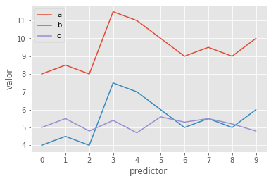

Este ejemplo pone de manifiesto que no existe una única medida de distancia que sea mejor que las demás, sino que depende del contexto en el que se utilice.

### Correlación Jackknife

El coeficiente de correlación de *Pearson* resulta efectivo como medida de similitud en ámbitos muy diversos. Sin embargo, tiene la desventaja de no ser robusto frente a *outliers*, a pesar de que se cumpla la condición de normalidad. Si dos variables tienen un pico o un valle común en una única observación, por ejemplo, por un error de lectura, la correlación va a estar dominada por este registro a pesar de que entre las dos variables no exista correlación real. Lo mismo puede ocurrir en la dirección opuesta. Si dos variables están altamente correlacionadas excepto para una observación, en la que los valores son muy dispares, entonces la correlación existente quedará enmascarada. Una forma de evitarlo es recurrir a la *Jackknife correlation*, que consiste en calcular todos los posibles coeficientes de correlación entre dos variables si se excluye cada vez una de las observaciones. El promedio de todas las *Jackknife correlations* atenúa en cierta medida el efecto del *outlier*.

$$\bar{\theta}_{(A,B)} = \text{Promedio Jackknife correlation (A,B)} = \frac{1}{n} \sum_{i=1}^n \hat r_i$$

donde $n$ es el número de observaciones y $\hat r_i$ es el coeficiente de correlación entre las variables $A$ y $B$, habiendo excluido la observación $i$.

Además del promedio, se puede estimar su error estándar ($SE$) y así obtener intervalos de confianza para la *Jackknife correlation* y su correspondiente *p-value*.

$$SE = \sqrt{\frac{n-1}{n} \sum_{i=1}^n (\hat r_i - \bar{\theta})^2}$$

Intervalo de confianza del 95% $(Z=1.96)$

$$\text{Promedio Jackknife correlation (A,B)} \pm \ 1.96 *SE$$$$\bar{\theta} - 1.96 \sqrt{\frac{n-1}{n} \sum_{i=1}^n (\hat r_i - \bar{\theta})^2} \ , \ \ \bar{\theta}+ 1.96 \sqrt{\frac{n-1}{n} \sum_{i=1}^n (\hat r_i - \bar{\theta})^2}$$

*P-value* para la hipótesis nula de que $\bar{\theta} = 0$:

$$Z_{calculada} = \frac{\bar{\theta} - H_0}{SE}= \frac{\bar{\theta} - 0}{\sqrt{\frac{n-1}{n} \sum_{i=1}^n (\hat r_i - \bar{\theta})^2}}$$$$p_{value} = P(Z > Z_{calculada})$$

Cuando se emplea este método, es conveniente calcular la diferencia entre el valor de correlación obtenido por *Jackknife correlation* $(\bar{\theta})$ y el que se obtiene si se emplean todas las observaciones $(\bar{r})$. A esta diferencia se le conoce como *Bias*. Su magnitud es un indicativo de cuanto está influenciada la estimación de la correlación entre dos variables debido a un valor atípico u *outlier*.

$$Bias = (n-1)*(\bar{\theta} - \hat{r})$$

Si se calcula la diferencia entre cada correlación $(\hat r_i)$ estimada en el proceso de *Jackknife* y el valor de correlación $(\hat r)$ obtenido si se emplean todas las observaciones, se puede identificar que observaciones son más influyentes.

Cuando el estudio requiere minimizar al máximo la presencia de falsos positivos, a pesar de que se incremente la de falsos negativos, se puede seleccionar como valor de correlación el menor de entre todos los calculados en el proceso de *Jackknife*.

$$\text{Correlacion} = \text{min} \{ \hat r_1, \hat r_2,..., \hat r_n \}$$

A pesar de que el método de *Jackknife* permite aumentar la robustez de la correlación de *Pearson*, si los *outliers* son muy extremos su influencia seguirá siendo notable.

### Simple matching coefficient

Cuando las variables con las que se pretende determinar la similitud entre observaciones son de tipo binario, a pesar de que es posible codificarlas de forma numérica como $1$ o $0$, no tiene sentido aplicar operaciones aritméticas sobre ellas (media, suma...). Por ejemplo, si la variable sexo se codifica como $1$ para mujer y $0$ para hombre, carece de significado decir que la media de la variable sexo en un determinado set de datos es $0.5$. En situaciones como esta, no se pueden emplear medidas de similitud basadas en distancia euclídea, manhattan, correlación...

Dadas dos observaciones *A* y *B*, cada uno con $n$ atributos binarios, el *simple matching coefficient (SMC)* define la similitud entre ellos como:

$$SMC= \frac{\text{número coincidencias}}{\text{número total de atributos}} = \frac{M_{00} + M{11}}{M_{00} + M_{01}+ M_{10}+M_{11}}$$

donde $M_{00}$ y $M_{11}$ son el número de variables para las que ambas observaciones tienen el mismo valor (ambas $0$ o ambas $1$), y $M_{01}$ y $M_{10}$ el número de variables que no coinciden. El valor de distancia *simple matching distance (SMD)* se corresponde con $1 - SMC$.

### Índice Jaccard

El índice *Jaccard* o coeficiente de correlación *Jaccard* es similar al *simple matching coefficient (SMC)*. La diferencia radica en que, el *SMC*, tiene el término $M_{00}$ en el numerador y denominador, mientras que el índice de *Jaccard* no. Esto significa que *SMC* considera como coincidencias tanto si el atributo está presente en ambos sets como si el atributo no está en ninguno de los sets, mientras que *Jaccard* solo cuenta como coincidencias cuando el atributo está presente en ambos sets.

$$J= \frac{M_{11}}{M_{01}+ M_{10}+M_{11}}$$

o en términos matemáticos de sets:

$$J(A,B) = \frac{A \cap B}{A \cup B}$$

La distancia de *Jaccard* ($1-J$) supera a la *simple matching distance* en aquellas situaciones en las que la coincidencia de ausencia no aporta información. Para ilustrar este hecho, supóngase que se quiere cuantificar la similitud entre dos clientes de un supermercado en base a los artículos comprados. Es de esperar que cada cliente solo adquiera unos pocos artículos de los muchos disponibles, por lo que el número de artículos no comprados por ninguno ($M_{00}$) será muy alto. Como la distancia de *Jaccard* ignora las coincidencias de tipo $M_{00}$, el grado de similitud dependerá únicamente de las coincidencias entre los artículos comprados.

### Distancia coseno

El coseno del ángulo que forman dos vectores puede interpretarse como una medida de similitud de sus orientaciones, independientemente de sus magnitudes. Si dos vectores tienen exactamente la misma orientación (el ángulo que forman es 0º) su coseno toma el valor de 1, si son perpendiculares (forman un ángulo de 90º) su coseno es 0 y si tienen orientaciones opuestas (ángulo de 180º) su coseno es de -1.

$$\text{cos}(\alpha) = \frac{\textbf{x} \cdot \textbf{y}}{||\textbf{x}|| \ ||\textbf{y}||}$$

Si los vectores se normalizan restandoles la media ($X − \bar{X}$), la medida recibe el nombre de coseno centrado y es equivalente a la correlación de Pearson.

### Escalado de las variables

La escala en la que se miden las variables y la magnitud de su varianza pueden afectar a los resultados obtenidos por *clustering*. Si una variable tiene una escala mucho mayor que el resto, determinará en gran medida el valor de distancia/similitud obtenido al comparar las observaciones, dirigiendo así la agrupación final. Escalar y centrar las variables antes de calcular la matriz de distancias para que tengan media 0 y desviación estándar 1, asegura que todas las variables tengan el mismo peso cuando se realice el *clustering*. [Sebastian Raschka](http://sebastianraschka.com/Articles/2014_about_feature_scaling.html) hace un análisis muy explicativo de los distintos tipos de escalado y normalización.

La forma más utilizada para escalar y centrar las variables es:

$$\frac{x_i - mean(x)}{sd(x)}$$

Aplicando esta transformación, existe una relación entre la distancia euclídea y la correlación de Pearson que hace que los resultados obtenidos por *clustering* sean equivalentes.

$$d_{euclídea}(p,q\ estandarizados) = \sqrt{2n(1-cor(p,q))}$$

### Ejemplo cálculo distancias

Dos de las librerías de python que implementan las distancias descritas en este documento (junto con otras) son [**sklearn.metrics.pairwise_distances**](https://scikit-learn.org/stable/modules/generated/sklearn.metrics.pairwise_distances.html#sklearn.metrics.pairwise_distances) y [**scipy.spatial.distance**](https://docs.scipy.org/doc/scipy/reference/spatial.distance.html). En concreto, *sklearn* permite calcular las distancias: ‘cityblock’, ‘cosine’, ‘euclidean’, ‘l1’, ‘l2’, ‘manhattan’, ‘braycurtis’, ‘canberra’, ‘chebyshev’, ‘correlation’, ‘dice’, ‘hamming’, ‘jaccard’, ‘kulsinski’, ‘mahalanobis’, ‘minkowski’, ‘rogerstanimoto’, ‘russellrao’, ‘seuclidean’, ‘sokalmichener’, ‘sokalsneath’, ‘sqeuclidean’ y ‘yule’.

**Librerías**

Las librerías utilizadas en este ejemplo son:

```python
# Tratamiento de datos
# ==============================================================================
import numpy as np
import pandas as pd
import statsmodels.api as sm

# Gráficos
# ==============================================================================
import matplotlib.pyplot as plt
import matplotlib.font_manager
from matplotlib import style
style.use('ggplot') or plt.style.use('ggplot')

# Preprocesado y modelado
# ==============================================================================
from sklearn.metrics import pairwise_distances
from sklearn.preprocessing import scale

# Configuración warnings
# ==============================================================================
import warnings
warnings.filterwarnings('ignore')
```

**Datos**

```python
USArrests = sm.datasets.get_rdataset("USArrests", "datasets")
datos = USArrests.data
datos.head(4)
```

|  | Murder | Assault | UrbanPop | Rape |
| --- | --- | --- | --- | --- |
| Alabama | 13.2 | 236 | 58 | 21.2 |
| Alaska | 10.0 | 263 | 48 | 44.5 |
| Arizona | 8.1 | 294 | 80 | 31.0 |
| Arkansas | 8.8 | 190 | 50 | 19.5 |

**Cálculo distancias**

```python
# Escalado de las variables
# ==============================================================================
datos_scaled = scale(X=datos, axis=0, with_mean=True, with_std=True)
datos_scaled = pd.DataFrame(datos_scaled, columns=datos.columns, index=datos.index)
datos_scaled.head(4)
```

|  | Murder | Assault | UrbanPop | Rape |
| --- | --- | --- | --- | --- |
| Alabama | 1.255179 | 0.790787 | -0.526195 | -0.003451 |
| Alaska | 0.513019 | 1.118060 | -1.224067 | 2.509424 |
| Arizona | 0.072361 | 1.493817 | 1.009122 | 1.053466 |
| Arkansas | 0.234708 | 0.233212 | -1.084492 | -0.186794 |

```python
# Cálculo de distancias
# ==============================================================================
print('------------------')
print('Distancia euclídea')
print('------------------')
distancias = pairwise_distances(
                X      = datos_scaled,
                metric ='euclidean'
             )

# Se descarta la diagonal superior de la matriz
distancias[np.triu_indices(n=distancias.shape[0])] = np.nan

distancias = pd.DataFrame(
                distancias,
                columns=datos_scaled.index,
                index = datos_scaled.index
            )

distancias.iloc[:4,:4]
```

```
------------------
Distancia euclídea
------------------
```

|  | Alabama | Alaska | Arizona | Arkansas |
| --- | --- | --- | --- | --- |
| Alabama | NaN | NaN | NaN | NaN |
| Alaska | 2.731204 | NaN | NaN | NaN |
| Arizona | 2.316805 | 2.728061 | NaN | NaN |
| Arkansas | 1.302905 | 2.854730 | 2.74535 | NaN |

Se reestructura la matriz de distancias para poder ordenar los pares de observaciones por orden de distancia.

```python
# Top n observaciones más similares
# ==============================================================================
distancias.melt(ignore_index=False, var_name="estado_b", value_name='distancia') \
    .rename_axis("estado_a") \
    .reset_index() \
    .dropna() \
    .sort_values('distancia') \
    .head(3)
```

|  | estado_a | estado_b | distancia |
| --- | --- | --- | --- |
| 728 | New Hampshire | Iowa | 0.207944 |
| 631 | New York | Illinois | 0.353774 |
| 665 | Kansas | Indiana | 0.433124 |

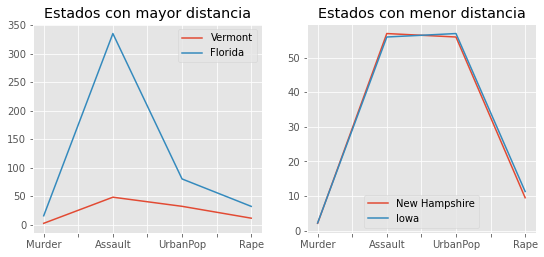

```python
# Estados con mayor y menor distancia
# ==============================================================================
fig, axs = plt.subplots(1,2, figsize=(9, 3.84))
datos.loc[['Vermont', 'Florida']].transpose().plot(ax= axs[0])
axs[0].set_title('Estados con mayor distancia')
datos.loc[['New Hampshire', 'Iowa']].transpose().plot(ax= axs[1])
axs[1].set_title('Estados con menor distancia');
```

## Número óptimo de clusters

Determinar el número óptimo de *clusters* es uno de los pasos más complicados a la hora de aplicar métodos de *clustering*, sobre todo cuando se trata de *partitioning clustering*, donde el número se tiene que especificar antes de poder ver los resultados. No existe una forma única de averiguar el número adecuado de *clusters*. Es un proceso bastante subjetivo que depende en gran medida del algoritmo empleado y de si se dispone de información previa sobre los datos con los que se está trabajando. A pesar de ello, se han desarrollado varias estrategias que ayudan en el proceso.

### Método Elbow

El método *Elbow*, también conocido como método del codo, sigue una estrategia comúnmente empleada para encontrar el valor óptimo de un hiperparámetro. La idea es probar un rango de valores del hiperparámetro en cuestión, representar gráficamente los resultados obtenidos con cada uno, e identificar aquel punto de la curva (codo) a partir del cual la mejora deja de ser notable. En los casos de *partitioning clustering*, como por ejemplo *K-means*, las observaciones se agrupan de una forma tal que se minimiza la varianza total *intra-cluster*. El método *Elbow* calcula la varianza total *intra-cluster* en función del número de *clusters* y escoge como óptimo aquel valor a partir del cual añadir más *clusters* apenas consigue mejoría.

### Método average silhouette

El método de *average silhouette* considera como número óptimo de *clusters* aquel que maximiza la media del *silhouette coeficient* de todas las observaciones.

El *silhouette coeficient* $(s_i)$ cuantifica cómo de buena es la asignación que se ha hecho de una observación comparando su similitud con el resto de observaciones de su *cluster* frente a las de los otros *clusters*. Su valor puede estar entre -1 y 1, siendo valores próximos a 1 un indicativo de que la observación se ha asignado al *cluster* correcto.

Para cada observación $i$, el *silhouette coeficient* $(s_i)$ se obtiene del siguiente modo:

- Calcular el promedio de las distancias (llámese $a_i$) entre la observación $i$ y el resto de observaciones que pertenecen al mismo *cluster*. Cuanto menor sea $a_i$, mejor ha sido la asignación de $i$ a su *cluster*.
- Calcular la distancia promedio entre la observación $i$ y el resto de *clusters*. Entendiendo por distancia promedio entre $i$ y un determinado *cluster* $C$ como la media de las distancias entre $i$ y las observaciones del *cluster* $C$.
- Identificar como $b_i$ a la menor de las distancias promedio entre $i$ y el resto de *clusters*, es decir, la distancia al *cluster* más próximo (*neighbouring cluster*).
- Calcular el valor de *silhouette* como:

$$s_i = \frac{b_i - a_i}{max(a_i, b_i)}$$

Se considera como número óptimo de *clusters* aquel que maximiza la media del *silhouette coeficient* de todas las observaciones.

### Estadístico gap

El estadístico *gap* fue publicado por *R.Tibshirani, G.Walther y T. Hastie*, autores también del magnífico libro *Introduction to Statistical Learning*. Este estadístico compara, para diferentes valores de *k*, la varianza total *intra-cluster* observada frente al valor esperado acorde a una distribución uniforme de referencia. La estimación del número óptimo de *clusters* es el valor *k* con el que se consigue maximizar el estadístico *gap*, es decir, encuentra el valor de *k* con el que se consigue una estructura de *clusters* lo más alejada posible de una distribución uniforme aleatoria. Este método puede aplicarse a cualquier tipo de *clustering*.

El algoritmo del *gap statistic method* es el siguiente:

- Hacer *clustering* de los datos para un rango de valores de $k$ ($k=1$, ..., $K=n$) y calcular para cada uno el valor de la varianza total *intra-cluster* ($W_k$).
- Simular $B$ sets de datos de referencia, todos ellos con una distribución aleatoria uniforme. Aplicar *clustering* a cada uno de los sets con el mismo rango de valores $k$ empleado en los datos originales, y calculando en cada caso la varianza total *intra-cluster* ($W_{kb}$). Se recomienda emplear valores de $B=500$.
- Calcular el estadístico *gap* para cada valor de $k$ como la desviación de la varianza observada $W_k$ respecto del valor esperado acorde a la distribución de referencia ($W_{kb}$). Calcular también su desviación estándar.

$$gap(k) = \frac{1}{B} \sum^B_{b=1}log(W_{kb})-log(W_k)$$

- Identificar el número de *clusters* óptimo como el menor de los valores $k$ para el que el estadístico *gap* se aleja menos de una desviación estándar del valor *gap* del siguiente $k$: $gap(k) \geq gap(k+1) - s_{k+1}$.

Los métodos *Elbow*, *Silhouette* y *gap* no tienen por qué coincidir exactamente en su estimación del número óptimo de *clusters*, pero tienden a acotar el rango de posibles valores. Por esta razón es recomendable calcular los tres y en función de los resultados decidir.

## K-means

El algoritmo *K-means* (MacQueen, 1967) agrupa las observaciones en un número predefinido de *K* *clusters* de forma que, la suma de las varianzas internas de los clusters, sea lo menor posible.

Existen varias implementaciones de este algoritmo, la más común de ellas se conoce como *Lloyd’s*. En la bibliografía es común encontrar los términos *inertia*, *within-cluster sum-of-squares* o varianza *intra-cluster* para referirse a la varianza interna de los *clusters*.

### Algoritmo

Considérense $C_1$,..., $C_K$ como los sets formados por los índices de las observaciones de cada uno de los *clusters*. Por ejemplo, el set $C_1$ contiene los índices de las observaciones agrupadas en el *cluster* 1. La nomenclatura empleada para indicar que la observación $i$ pertenece al *cluster* $k$ es: $i \in C_k$. Todos los sets satisfacen dos propiedades:

- $C_1 \cup C_2 \cup ... \cup C_K = \{1,...,n\}$. Significa que toda observación pertenece a uno de los *K* *clusters*.
- $C_k \cap C_{k'} = \emptyset$ para todo $k \neq k'$. Implica que los *clusters* no solapan, ninguna observación pertenece a más de un *cluster* a la vez.

Dos de las medidas comúnmente empleadas para cuantificar la varianza interna de un *cluster* ($W(C_k)$) son:

- La suma de las distancias euclídeas al cuadrado entre cada observación ($x_i$) y el centroide ($\mu$) de su *cluster*. Esto equivale a la suma de cuadrados internos del *cluster* y es la métrica que utiliza scikitlearn.

$$W(C_k) = \sum_{x_i,\in C_k} (x_{i} - \mu_k)^2$$

- La suma de las distancias euclídeas al cuadrado entre todos los pares de observaciones que forman el *cluster*, dividida entre el número de observaciones del *cluster*.

$$W(C_k) = \frac{1}{|C_k|} \sum_{i,i' \in C_k} \sum^p_{j=1}(x_{ij} - x_{i'j})^2$$

Minimizar la suma total de varianza interna $\sum^k_{k=1}W(C_k)$ de forma exacta (encontrar el mínimo global) es un proceso muy complejo debido a la inmensa cantidad de formas en las que *n* observaciones se pueden repartir en *K* grupos. En lugar de esto, *k-means* trata de encontrar una solución que, aun no siendo la mejor de entre todas las posibles, sea buena (óptimo local). El algoritmo empleado es:

1. Especificar el número *K* de *clusters* que se quieren crear.
2. Seleccionar de forma aleatoria *k* observaciones del set de datos como centroides iniciales.
3. Asignar cada una de las observaciones al centroide más cercano.
4. Para cada uno de los *K clusters* generados en el paso 3, recalcular su centroide.
5. Repetir los pasos 3 y 4 hasta que las asignaciones no cambien o se alcance el número máximo de iteraciones establecido.

Este algoritmo garantiza que, en cada paso, se reduzca la intra-varianza total de los *clusters* hasta alcanzar un *óptimo local*. Debido a que el algoritmo de *K-means* no evalúa todas las posibles distribuciones de las observaciones sino solo parte de ellas, los resultados obtenidos dependen de la asignación aleatoria inicial (paso 2). Por esta razón, es importante ejecutar el algoritmo varias veces (25-50), cada una con una asignación aleatoria inicial distinta, y seleccionar aquella que haya conseguido una menor varianza total.

### Ventajas y desventajas

*K-means* es uno de los métodos de *clustering* más utilizados. Destaca por la sencillez y velocidad de su algoritmo, sin embargo, presenta una serie de limitaciones que se deben tener en cuenta.

- Requiere que se indique de antemano el número de *clusters* que se van a crear. Esto puede ser complicado si no se dispone de información adicional sobre los datos con los que se trabaja. Se han desarrollado varias estrategias para ayudar a identificar potenciales valores óptimos de *K* (*elbow*, *shilouette*), pero todas ellas son orientativas.
- Dificultad para detectar *clusters* alargados o con formas irregulares.
- Las agrupaciones resultantes pueden variar dependiendo de la asignación aleatoria inicial de los centroides. Para minimizar este problema, se recomienda repetir el proceso de *clustering* entre 25-50 veces y seleccionar como resultado definitivo el que tenga menor suma total de varianza interna. Aun así, solo se puede garantizar la reproducibilidad de los resultados si se emplean semillas.
- Presenta problemas de robustez frente a *outliers*. La única solución es excluirlos o recurrir a otros métodos de *clustering* más robustos como *K-medoids (PAM)*.

### Ejemplo

Los siguientes datos simulados contienen observaciones que pertenecen a cuatro grupos distintos. Se pretende aplicar *K-means-clustering* con el objetivo de identificar las agrupaciones reales.

**Librerías**

Las librerías utilizadas en este ejemplo son:

```python
# Tratamiento de datos
# ==============================================================================
import numpy as np
import pandas as pd
from sklearn.datasets import make_blobs

# Gráficos
# ==============================================================================
import matplotlib.pyplot as plt
from matplotlib import style
style.use('ggplot') or plt.style.use('ggplot')

# Preprocesado y modelado
# ==============================================================================
from sklearn.cluster import KMeans
from sklearn.preprocessing import scale
from sklearn.metrics import silhouette_score

# Configuración warnings
# ==============================================================================
import warnings
warnings.filterwarnings('ignore')
```

**Datos**

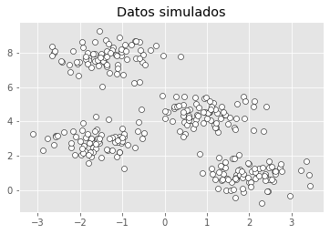

```python
# Simulación de datos
# ==============================================================================
X, y = make_blobs(
        n_samples    = 300,
        n_features   = 2,
        centers      = 4,
        cluster_std  = 0.60,
        shuffle      = True,
        random_state = 0
       )

fig, ax = plt.subplots(1, 1, figsize=(6, 3.84))
ax.scatter(
    x = X[:, 0],
    y = X[:, 1],
    c = 'white',
    marker    = 'o',
    edgecolor = 'black',
)
ax.set_title('Datos simulados');
```

**Modelo Kmeans**

Con la clase `sklearn.cluster.KMeans` de Scikit-Learn se pueden entrenar modelos de *clustering* utilizando el algoritmo *k-means*. Entre sus parámetros destacan:

- `n_clusters`: determina el número $K$ de *clusters* que se van a generar.
- `init`: estrategia para asignar los centroides iniciales. Por defecto se emplea 'k-means++', una estrategia que trata de alejar los centroides lo máximo posible facilitando la convergencia. Sin embargo, esta estrategia puede ralentizar el proceso cuando hay muchos datos, si esto ocurre, es mejor utilizar 'random'.
- `n_init`: determina el número de veces que se va a repetir el proceso, cada vez con una asignación aleatoria inicial distinta. Es recomendable que este último valor sea alto, entre 10-25, para no obtener resultados subóptimos debido a una iniciación poco afortunada del proceso.
- `max_iter`: número máximo de iteraciones permitidas.
- `random_state`: semilla para garantizar la reproducibilidad de los resultados.

```python
# Escalado de datos
# ==============================================================================
X_scaled = scale(X)
```

```python
# Modelo
# ==============================================================================
X_scaled = scale(X)
modelo_kmeans = KMeans(n_clusters=4, n_init=25, random_state=123)
modelo_kmeans.fit(X=X_scaled)
```

```
KMeans(n_clusters=4, n_init=25, random_state=123)
```

El objeto devuelto por `KMeans()` contiene entre otros datos: la media de cada una de las variables para cada *cluster* (`cluster_centers_`), es decir, los centroides. Un vector indicando a qué *cluster* se ha asignado cada observación (`.labels_`) y la suma total de cuadrados internos de todos los clusters (`.inertia_`).

**Número de clusters**

Al tratarse de una simulación, se conoce el verdadero número de grupos (4) y a cuál de ellos pertenece cada observación. Esto no sucede en la mayoría de casos prácticos, pero es útil como ejemplo ilustrativo cómo funciona *K-means*.

```python
# Clasificación con el modelo kmeans
# ==============================================================================
y_predict = modelo_kmeans.predict(X=X_scaled)
```

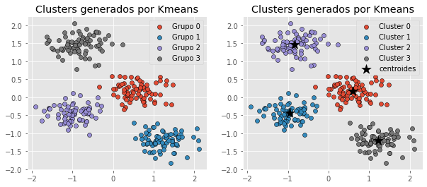

```python
# Representación gráfica: grupos originales vs clusters creados
# ==============================================================================
fig, ax = plt.subplots(1, 2, figsize=(10, 4))

# Grupos originales
for i in np.unique(y):
    ax[0].scatter(
        x = X_scaled[y == i, 0],
        y = X_scaled[y == i, 1],
        c = plt.rcParams['axes.prop_cycle'].by_key()['color'][i],
        marker    = 'o',
        edgecolor = 'black',
        label= f"Grupo {i}"
    )

ax[0].set_title('Clusters generados por Kmeans')
ax[0].legend();

for i in np.unique(y_predict):
    ax[1].scatter(
        x = X_scaled[y_predict == i, 0],
        y = X_scaled[y_predict == i, 1],
        c = plt.rcParams['axes.prop_cycle'].by_key()['color'][i],
        marker    = 'o',
        edgecolor = 'black',
        label= f"Cluster {i}"
    )

ax[1].scatter(
    x = modelo_kmeans.cluster_centers_[:, 0],
    y = modelo_kmeans.cluster_centers_[:, 1],
    c = 'black',
    s = 200,
    marker = '*',
    label  = 'centroides'
)
ax[1].set_title('Clusters generados por Kmeans')
ax[1].legend();
```

Este tipo de visualización es muy útil e informativa, sin embargo, solo es posible cuando se trabaja con dos dimensiones. Si los datos contienen más de dos variables (dimensiones), una posible solución es utilizar las dos primeras componentes principales obtenidas con un [PCA](https://www.cienciadedatos.net/documentos/py19-pca-python.html) previo.

El número de aciertos y errores puede representarse en modo de matriz de confusión. A la hora de interpretar estas matrices, es importante recordar que el *clustering* asigna las observaciones a *clusters* cuyo identificador no tiene porqué coincidir con la nomenclatura empleada para los grupos reales. En este ejemplo, el grupo 1 se ha asignado al cluster 3. Así pues, por cada fila de la matriz cabe esperar un valor alto (coincidencias) para una de las posiciones y valores bajos en las otras (errores de clasificación), pero no tienen por qué coincidir los nombres (diagonal).

```python
# Matriz de confusión: grupos originales vs clusters creados
# ==============================================================================
pd.crosstab(y, y_predict, dropna=False, rownames=['grupo_real'], colnames=['cluster'])
```

| cluster grupo_real | 0 | 1 | 2 | 3 |
| --- | --- | --- | --- | --- |
| 0 | 75 | 0 | 0 | 0 |
| 1 | 0 | 0 | 0 | 75 |
| 2 | 0 | 75 | 0 | 0 |
| 3 | 0 | 0 | 75 | 0 |

En este análisis, todas las observaciones se han clasificado correctamente. De nuevo repetir que, en la realidad, no se suelen conocer los verdaderos grupos en los que se dividen las observaciones, de lo contrario no se necesitaría aplicar *clustering*.

Supóngase ahora que se trata de un caso real, en el que se desconoce el número de grupos en los que se subdividen las observaciones. El analista tendría que probar con diferentes valores de $K$ y decidir cuál parece más razonable. A continuación, se muestran los resultados para $K=2$ y $K=6$.

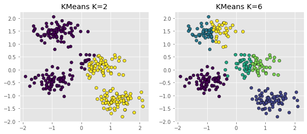

```python
fig, ax = plt.subplots(1, 2, figsize=(10, 4))

# Resultados para K = 2
# ==============================================================================
y_predict = KMeans(n_clusters=2, n_init=25, random_state=123).fit_predict(X=X_scaled)
ax[0].scatter(
        x = X_scaled[:, 0],
        y = X_scaled[:, 1],
        c = y_predict,
        #cmap='viridis',
        marker    = 'o',
        edgecolor = 'black'
    )
ax[0].set_title('KMeans K=2');

# Resultados para K = 6
# ==============================================================================
y_predict = KMeans(n_clusters=6, n_init=25, random_state=123).fit_predict(X=X_scaled)
ax[1].scatter(
        x = X_scaled[:, 0],
        y = X_scaled[:, 1],
        c = y_predict,
        #cmap='viridis',
        marker    = 'o',
        edgecolor = 'black'
    )
ax[1].set_title('KMeans K=6');
```

Al observar los resultados obtenidos para *K = 2*, es intuitivo pensar que el grupo que se encuentra entorno a las coordenadas $x = 0.5, y = 0$ (mayoritariamente considerado como amarillo) debería ser un grupo separado. Para *K = 6* no parece muy razonable la separación de los grupos amarillo y azul. Este ejemplo muestra la principal limitación del método de *K-means*, el hecho de tener que escoger de antemano el número de *clusters* que se generan.

La deducción anterior solo puede hacerse visualmente cuando se trata de dos dimensiones. Una forma sencilla de estimar el número K óptimo de clusters cuando no se dispone de esta información, es aplicar el algoritmo de *K-means* para un rango de valores de *K* e identificar aquel valor a partir del cual la reducción en la suma total de varianza intra-cluster (*inertia*) deja de ser sustancial. A esta estrategia se la conoce como método del codo o *elbow method*.

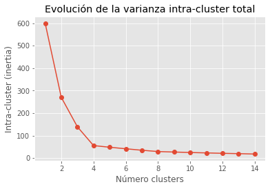

```python
# Método elbow para identificar el número óptimo de clusters
# ==============================================================================
range_n_clusters = range(1, 15)
inertias = []

for n_clusters in range_n_clusters:
    modelo_kmeans = KMeans(
                        n_clusters   = n_clusters,
                        n_init       = 20,
                        random_state = 123
                    )
    modelo_kmeans.fit(X_scaled)
    inertias.append(modelo_kmeans.inertia_)

fig, ax = plt.subplots(1, 1, figsize=(6, 3.84))
ax.plot(range_n_clusters, inertias, marker='o')
ax.set_title("Evolución de la varianza intra-cluster total")
ax.set_xlabel('Número clusters')
ax.set_ylabel('Intra-cluster (inertia)');
```

A partir de 4 clusters la reducción en la suma total de cuadrados internos parece estabilizarse, indicando que *K* = 4 es una buena opción.

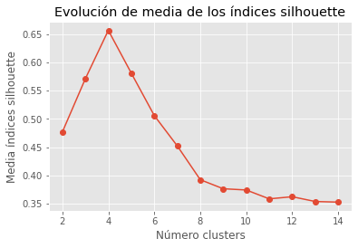

```python
# Método silhouette para identificar el número óptimo de clusters
# ==============================================================================
range_n_clusters = range(2, 15)
valores_medios_silhouette = []

for n_clusters in range_n_clusters:
    modelo_kmeans = KMeans(
                        n_clusters   = n_clusters,
                        n_init       = 20,
                        random_state = 123
                    )
    cluster_labels = modelo_kmeans.fit_predict(X_scaled)
    silhouette_avg = silhouette_score(X_scaled, cluster_labels)
    valores_medios_silhouette.append(silhouette_avg)

fig, ax = plt.subplots(1, 1, figsize=(6, 3.84))
ax.plot(range_n_clusters, valores_medios_silhouette, marker='o')
ax.set_title("Evolución de media de los índices silhouette")
ax.set_xlabel('Número clusters')
ax.set_ylabel('Media índices silhouette');
```

El valor medio de los índices *silhouette* se maximiza con 4 clusters. Acorde a este criterio, *K* = 4 es la mejor opción.

## K-medoids

### Algoritmo

*K-medoids* es un método de *clustering* muy similar a *K-means* en cuanto a que ambos agrupan las observaciones en *K* *clusters*, donde *K* es un valor preestablecido por el analista. La diferencia es que, en *K-medoids*, cada *cluster* está representado por una observación presente en el *cluster* (*medoid*), mientras que en *K-means* cada *cluster* está representado por su centroide, que se corresponde con el promedio de todas las observaciones del *cluster* pero con ninguna en particular.

Una definición más exacta del término *medoid* es: elemento dentro de un *cluster* cuya distancia (diferencia) promedio entre él y todos los demás elementos del mismo *cluster* es lo menor posible. Se corresponde con el elemento más central del *cluster* y por lo tanto puede considerarse como el más representativo. El hecho de utilizar *medoids* en lugar de centroides hace de *K-medoids* un método más robusto que *K-means*, viéndose menos afectado por *outliers* o ruido. A modo de idea intuitiva puede considerarse como la analogía entre media y mediana.

El algoritmo más empleado para aplicar *K-medoids* se conoce como *PAM* (*Partitioning Around Medoids*) y sigue los siguientes pasos:

1. Seleccionar *K* observaciones aleatorias como *medoids* iniciales. También es posible identificarlas de forma específica.
2. Calcular la matriz de distancia entre todas las observaciones si esta no se ha calculado anteriormente.
3. Asignar cada observación a su *medoid* más cercano.
4. Para cada uno de los *clusters* creados, comprobar si seleccionando otra observación como *medoid* se consigue reducir la distancia promedio del *cluster*, si esto ocurre, seleccionar la observación que consigue una mayor reducción como nuevo *medoid*.
5. Si al menos un *medoid* ha cambiado en el paso 4, volver al paso 3, de lo contrario, se termina el proceso.

A diferencia del algoritmo *K-means*, en el que se minimiza la suma total de cuadrados intra-cluster (suma de las distancias al cuadrado de cada observación respecto a su centroide), el algoritmo *K-medoids* minimiza la suma de las diferencias de cada observación respecto a su *medoid*.

Por lo general, el método de *K-medoids* se utiliza cuando se conoce o se sospecha de la presencia de *outliers*. Si esto ocurre, es recomendable utilizar como medida de similitud la distancia de *Manhattan*, ya que es menos sensible a *outliers* que la euclídea.

### Ventajas y desventajas

- *K-medoids* es un método de *clustering* más robusto que *K-means*, por lo es más adecuado cuando el set de datos contiene *outliers* o ruido.
- Al igual que *K-means*, necesita que se especifique de antemano el número de *clusters* que se van a crear. Esto puede ser complicado de determinar si no se dispone de información adicional sobre los datos. Muchas de las estrategias empleadas en *K-means* para identificar el número óptimo, pueden aplicarse en *K-medoids*.
- Para sets de datos grandes se necesitan muchos recursos computacionales. En tal situación se recomienda aplicar el método *CLARA*.

El algoritmo *K-medoids* está implementado en la clase `KMedoids` de la librería `sklearn_extra`. Su funcionamiento es análogo al descrito en el apartado de *K-means*. También está disponible en la librería `PyClustering`.

## Hierarchical clustering

*Hierarchical clustering* es una alternativa a los métodos de *partitioning clustering* que no requiere que se pre-especifique el número de *clusters*. Los métodos que engloba el *hierarchical clustering* se subdividen en dos tipos dependiendo de la estrategia seguida para crear los grupos:

- Aglomerativo (*agglomerative clustering* o *bottom-up*): el agrupamiento se inicia con todas las observaciones separadas, cada una formando un *cluster* individual. Los *clusters* se van combinado a medida que la estructura crece hasta converger en uno solo.
- Divisivo (*divisive clustering o* top-down*): es la estrategia opuesta al aglomerativo. Se inicia con todas las observaciones contenidas en un mismo* cluster *y se suceden divisiones hasta que cada observación forma un* cluster* individual.

En ambos casos, los resultados pueden representarse de forma muy intuitiva en una estructura de árbol llamada dendrograma.

### Aglomerativo

El algoritmo seguido para por el *clustering* aglomerativo es:

1. Considerar cada una de las *n* observaciones como un *cluster* individual, formando así la base del dendrograma (hojas).
2. Proceso iterativo hasta que todas las observaciones pertenecen a un único *cluster*:

   2.1 Calcular la distancia entre cada posible par de los *n* *clusters*. El investigador debe determinar el tipo de medida empleada para cuantificar la similitud entre observaciones o grupos (distancia y *linkage*).

   2.2 Los dos *clusters* más similares se fusionan, de forma que quedan *n*-1 *clusters.*
3. Cortar la estructura de árbol generada (dendrograma) a una determinada altura para crear los *clusters* finales.

Para que el proceso de agrupamiento pueda llevarse a cabo tal como indica el algoritmo anterior, es necesario definir cómo se cuantifica la similitud entre dos *clusters*. Es decir, se tiene que extender el concepto de distancia entre pares de observaciones para que sea aplicable a pares de grupos, cada uno formado por varias observaciones. A este proceso se le conoce como *linkage*. A continuación, se describen los 5 tipos de *linkage* más empleados y sus definiciones.

- **Complete or Maximum**: se calcula la distancia entre todos los posibles pares formados por una observación del *cluster A* y una del *cluster B*. La mayor de todas ellas se selecciona como la distancia entre los dos *clusters*. Se trata de la medida más conservadora (*maximal intercluster dissimilarity*).
- **Single or Minimum**: se calcula la distancia entre todos los posibles pares formados por una observación del *cluster A* y una del *cluster B*. La menor de todas ellas se selecciona como la distancia entre los dos *clusters*. Se trata de la medida menos conservadora (*minimal intercluster dissimilarity*).
- **Average**: Se calcula la distancia entre todos los posibles pares formados por una observación del *cluster A* y una del *cluster B*. El valor promedio de todas ellas se selecciona como la distancia entre los dos *clusters* (*mean intercluster dissimilarity*).
- **Centroid**: Se calcula el centroide de cada uno de los *clusters* y se selecciona la distancia entre ellos como la distancia entre los dos *clusters*.
- **Ward**: Se trata de un método general. La selección del par de *clusters* que se combinan en cada paso del *agglomerative hierarchical clustering* se basa en el valor óptimo de una función objetivo, pudiendo ser esta última cualquier función definida por el analista. El método *Ward's minimum variance* es un caso particular en el que el objetivo es minimizar la suma total de varianza *intra-cluster*. En cada paso, se identifican aquellos 2 *clusters* cuya fusión conlleva menor incremento de la varianza total *intra-cluster*. Esta es la misma métrica que se minimiza en *K-means*.

Los métodos de *complete*, *average* y *Ward's minimum variance* suelen ser los preferidos por los analistas debido a que generan dendrogramas más compensados. Sin embargo, no se puede determinar que uno sea mejor que otro, ya que depende del caso de estudio en cuestión. Por ejemplo, en genómica, se emplea con frecuencia el método de *centroides*. Junto con los resultados de un proceso de *hierarchical clustering* siempre hay que indicar qué distancia se ha empleado, así como el tipo de *linkage*, ya que, dependiendo de estos, los resultados pueden variar en gran medida.

### Divisivo

El algoritmo más conocido de *divisive hierarchical clustering* es *DIANA* (*DIvisive ANAlysis Clustering*). Este algoritmo se inicia con un único *cluster* que contiene todas las observaciones. A continuación, se van sucediendo divisiones hasta que cada observación forma un *cluster* independiente. En cada iteración, se selecciona el *cluster* con mayor diámetro, entendiendo por diámetro de un *cluster* la mayor de las diferencias entre dos de sus observaciones. Una vez seleccionado el *cluster*, se identifica la observación más dispar, que es aquella con mayor distancia promedio respecto al resto de observaciones que forman el *cluster*. Esta observación inicia el nuevo *cluster*. Se reasignan las observaciones en función de si están más próximas al nuevo *cluster* o al resto de la partición, dividiendo así el *cluster* seleccionado en dos nuevos *clusters.*

1. Todas las *n* observaciones forman un único *cluster*.
2. Repetir hasta que haya *n* *clusters*:
   - 2.1 Calcular para cada *cluster* la mayor de las distancias entre pares de observaciones (diámetro del *cluster*).
   - 2.2 Seleccionar el *cluster* con mayor diámetro.
   - 2.3 Calcular la distancia media de cada observación respecto a las demás.
   - 2.4 La observación más distante inicia un nuevo *cluster*.
   - 2.5 Se reasignan las observaciones restantes al nuevo *cluster* o al viejo dependiendo de cuál está más próximo.

A diferencia del *clustering* aglomerativo, en el que hay que elegir un tipo de distancia y un método de *linkage*, en el *clustering* divisivo solo hay que elegir la distancia, no hay *linkage*.

### Dendrograma

Los resultados del *hierarchical clustering* pueden representarse como un árbol en el que las ramas representan la jerarquía con la que se van sucediendo las uniones de *clusters*.

Supóngase que se dispone de 45 observaciones en un espacio de dos dimensiones, a los que se les aplica *hierarchical clustering* para intentar identificar grupos. El siguiente dendrograma representa los resultados obtenidos.

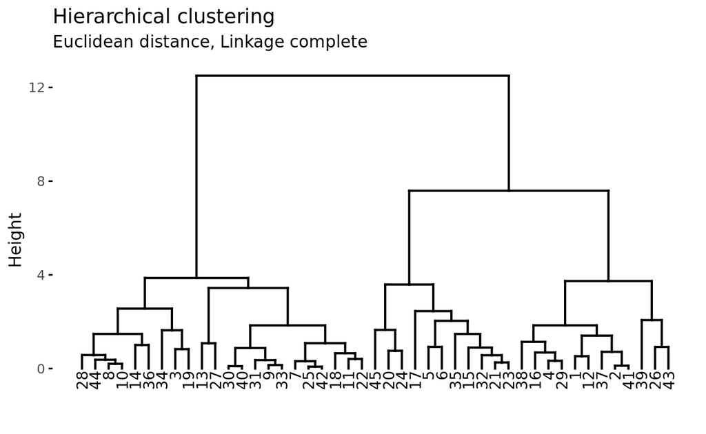

En la base del dendrograma, cada observación forma una terminación individual conocida como hoja o *leaf* del árbol. A medida que se asciende por la estructura, pares de hojas se fusionan formando las primeras ramas. Estas uniones se corresponden con los pares de observaciones más similares. También ocurre que las ramas se fusionan con otras ramas o con hojas. Cuanto más temprana (más próxima a la base del dendrograma) ocurre una fusión, mayor es la similitud.

Para cualquier par de observaciones, se puede identificar el punto del árbol en el que las ramas que contienen dichas observaciones se fusionan. La altura a la que esto ocurre (eje vertical) indica cómo de similares/diferentes son las dos observaciones. Los dendrogramas, por lo tanto, se deben interpretar únicamente en base al eje vertical y no por las posiciones que ocupan las observaciones en el eje horizontal, esto último es simplemente por estética y puede variar de un programa a otro.

Por ejemplo, la observación 8 es la más similar a la 10 ya que es la primera fusión que recibe la observación 10 (y viceversa). Podría resultar tentador decir que la observación 14, situada inmediatamente a la derecha de la 10, es la siguiente más similar, sin embargo, las observaciones 28 y 44 son más similares a la 10 a pesar de que se encuentran más alejadas en el eje horizontal. Del mismo modo, no es correcto decir que la observación 14 es más similar a la observación 10 de lo que lo es la 36 por el hecho de que está más próxima en el eje horizontal. Prestando atención a la altura en que las respectivas ramas se unen, la única conclusión válida es que la similitud entre los pares 10-14 y 10-36 es la misma.

### Cortar el dendograma para generar los clusters

Además de representar en un dendrograma la similitud entre observaciones, se tiene que identificar el número de *clusters* creados y qué observaciones forman parte de cada uno. Si se realiza un corte horizontal a una determinada altura del dendrograma, el número de ramas que sobrepasan (en sentido ascendente) dicho corte se corresponde con el número de *clusters*. La siguiente imagen muestra dos veces el mismo dendrograma. Si se realiza el corte a la altura de 5, se obtienen dos *clusters*, mientras que si se hace a la de 3.5 se obtienen 4. La altura de corte tiene por lo tanto la misma función que el valor *K* en *K-means-clustering*: controla el número de clusters obtenidos.

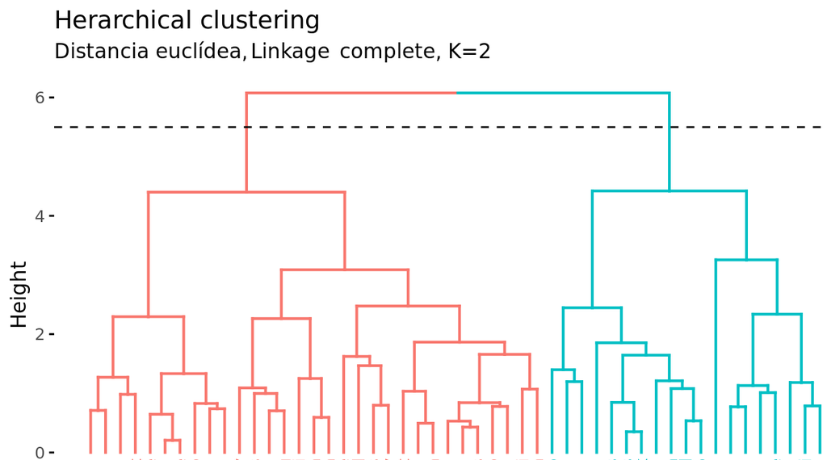

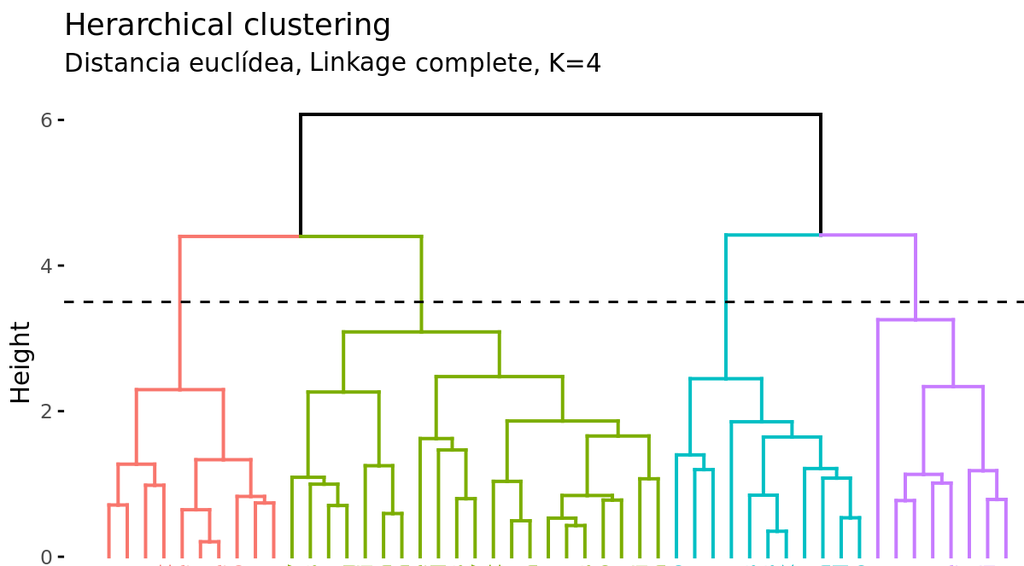

Dos propiedades adicionales se derivan de la forma en que se generan los *clusters* en el método de *hierarchical clustering*:

- Dada la longitud variable de las ramas, siempre existe un intervalo de altura para el que cualquier corte da lugar al mismo número de *clusters*. En el ejemplo anterior, todos los cortes entre las alturas 5 y 6 tienen como resultado los mismos 2 *clusters*.
- Con un solo dendrograma se dispone de la flexibilidad para generar cualquier número de *clusters* desde 1 a *n*. La selección del número óptimo puede valorarse de forma visual, tratando de identificar las ramas principales en base a la altura a la que ocurren las uniones. En el ejemplo expuesto es razonable elegir entre 2 o 4 *clusters*.

### Ejemplo

Los siguientes datos simulados contienen observaciones que pertenecen a cuatro grupos distintos. Se pretende aplicar *hierarchical clustering aglomerativo* con el objetivo de identificar las agrupaciones reales.

**Librerías**

Las librerías utilizadas en este ejemplo son:

```python
# Tratamiento de datos
# ==============================================================================
import numpy as np
import pandas as pd
from sklearn.datasets import make_blobs

# Gráficos
# ==============================================================================
import matplotlib.pyplot as plt
from matplotlib import style
style.use('ggplot') or plt.style.use('ggplot')

# Preprocesado y modelado
# ==============================================================================
from sklearn.cluster import AgglomerativeClustering
from scipy.cluster.hierarchy import dendrogram
from sklearn.preprocessing import scale
from sklearn.metrics import silhouette_score

# Configuración warnings
# ==============================================================================
import warnings
warnings.filterwarnings('ignore')
```

```python
def plot_dendrogram(model, **kwargs):
    '''
    Esta función extrae la información de un modelo AgglomerativeClustering
    y representa su dendograma con la función dendogram de scipy.cluster.hierarchy
    '''

    counts = np.zeros(model.children_.shape[0])
    n_samples = len(model.labels_)
    for i, merge in enumerate(model.children_):
        current_count = 0
        for child_idx in merge:
            if child_idx < n_samples:
                current_count += 1  # leaf node
            else:
                current_count += counts[child_idx - n_samples]
        counts[i] = current_count

    linkage_matrix = np.column_stack([model.children_, model.distances_,
                                      counts]).astype(float)

    # Plot
    dendrogram(linkage_matrix, **kwargs)
```

**Datos**

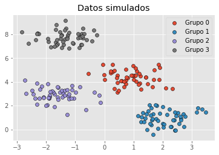

```python
# Simulación de datos
# ==============================================================================
X, y = make_blobs(
        n_samples    = 200,
        n_features   = 2,
        centers      = 4,
        cluster_std  = 0.60,
        shuffle      = True,
        random_state = 0
       )

fig, ax = plt.subplots(1, 1, figsize=(6, 3.84))
for i in np.unique(y):
    ax.scatter(
        x = X[y == i, 0],
        y = X[y == i, 1],
        c = plt.rcParams['axes.prop_cycle'].by_key()['color'][i],
        marker    = 'o',
        edgecolor = 'black',
        label= f"Grupo {i}"
    )
ax.set_title('Datos simulados')
ax.legend();
```

**Modelo**

Con la clase `sklearn.cluster.AgglomerativeClustering` de Scikit-Learn se pueden entrenar modelos de *clustering* utilizando el algoritmo *hierarchical clustering* aglomerativo. Entre sus parámetros destacan:

- `n_clusters`: determina el número de *clusters* que se van a generar. En su lugar, su valor puede ser `None` si se quiere utilizar el criterio `distance_threshold` para crear los clusters o crecer todo el dendograma.
- `distance_threshold`: distancia (altura del dendograma) a partir de la cual se dejan de unir los *clusters*. Indicar `distance_threshold=0` para crecer todo el árbol.
- `compute_full_tree`: si se calcula la jerarquía completa de *clusters*. Debe ser `True` si `distance_threshold` es distinto de `None`.
- `affinity`: métrica utilizada como distancia. Puede ser: “euclidean”, “l1”, “l2”, “manhattan”, “cosine”, or “precomputed”. Si se utiliza `linkage=“ward”`, solo se permite “euclidean”.
- `linkage`: tipo de *linkage* utilizado. Puede ser “ward”, “complete”, “average” o “single”.

Al aplicar un *hierarchical clustering* aglomerativo se tiene que escoger una medida de distancia y un tipo de *linkage*. A continuación, se comparan los resultados con los *linkages* *complete*, *ward* y *average*, utilizando la distancia euclídea como métrica de similitud.

```python
# Escalado de datos
# ==============================================================================
X_scaled = scale(X)
```

```python
# Modelos
# ==============================================================================
modelo_hclust_complete = AgglomerativeClustering(
                            affinity = 'euclidean',
                            linkage  = 'complete',
                            distance_threshold = 0,
                            n_clusters         = None
                        )
modelo_hclust_complete.fit(X=X_scaled)

modelo_hclust_average = AgglomerativeClustering(
                            affinity = 'euclidean',
                            linkage  = 'average',
                            distance_threshold = 0,
                            n_clusters         = None
                        )
modelo_hclust_average.fit(X=X_scaled)

modelo_hclust_ward = AgglomerativeClustering(
                            affinity = 'euclidean',
                            linkage  = 'ward',
                            distance_threshold = 0,
                            n_clusters         = None
                     )
modelo_hclust_ward.fit(X=X_scaled)
```

```
AgglomerativeClustering(distance_threshold=0, n_clusters=None)
```

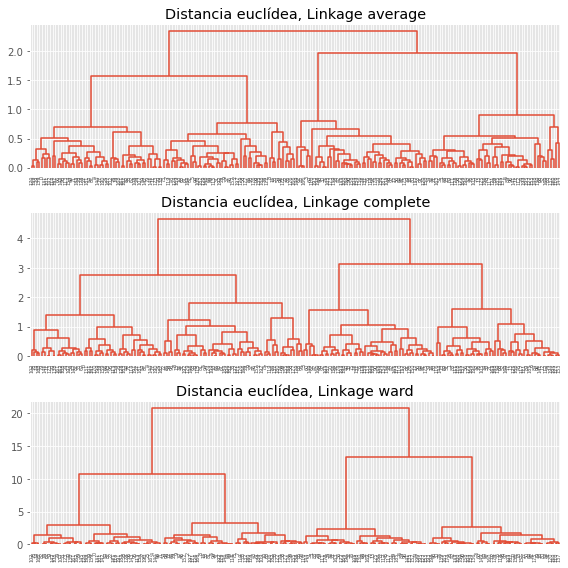

```python
# Dendrogramas
# ==============================================================================
fig, axs = plt.subplots(3, 1, figsize=(8, 8))
plot_dendrogram(modelo_hclust_average, color_threshold=0, ax=axs[0])
axs[0].set_title("Distancia euclídea, Linkage average")
plot_dendrogram(modelo_hclust_complete, color_threshold=0, ax=axs[1])
axs[1].set_title("Distancia euclídea, Linkage complete")
plot_dendrogram(modelo_hclust_ward, color_threshold=0, ax=axs[2])
axs[2].set_title("Distancia euclídea, Linkage ward")
plt.tight_layout();
```

En este caso, los tres tipos de *linkage* identifican claramente 4 clusters, si bien esto no significa que en los 3 dendrogramas los clusters estén formados por exactamente las mismas observaciones.

**Número de clusters**

Una forma de identificar el número de clusters, es inspeccionar visualmente el dendograma y decidir a qué altura se corta para generar los *clusters*. Por ejemplo, para los resultados generados mediante distancia euclídea y *linkage ward*, parece sensato cortar el dendograma a una altura de entre 5 y 10, de forma que se creen 4 clusters.

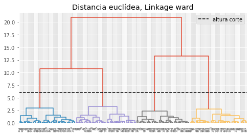

```python
fig, ax = plt.subplots(1, 1, figsize=(8, 4))
altura_corte = 6
plot_dendrogram(modelo_hclust_ward, color_threshold=altura_corte, ax=ax)
ax.set_title("Distancia euclídea, Linkage ward")
ax.axhline(y=altura_corte, c = 'black', linestyle='--', label='altura corte')
ax.legend();
```

Otra forma de identificar potenciales valores óptimos para el número de *clusters* en modelos *hierarchical clustering* es mediante los índices *silhouette*.

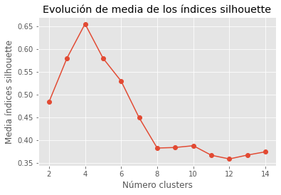

```python
# Método silhouette para identificar el número óptimo de clusters
# ==============================================================================
range_n_clusters = range(2, 15)
valores_medios_silhouette = []

for n_clusters in range_n_clusters:
    modelo = AgglomerativeClustering(
                    affinity   = 'euclidean',
                    linkage    = 'ward',
                    n_clusters = n_clusters
             )

    cluster_labels = modelo.fit_predict(X_scaled)
    silhouette_avg = silhouette_score(X_scaled, cluster_labels)
    valores_medios_silhouette.append(silhouette_avg)

fig, ax = plt.subplots(1, 1, figsize=(6, 3.84))
ax.plot(range_n_clusters, valores_medios_silhouette, marker='o')
ax.set_title("Evolución de media de los índices silhouette")
ax.set_xlabel('Número clusters')
ax.set_ylabel('Media índices silhouette');
```

Una vez identificado el número óptimo de clusters, se reentrena el modelo indicando este valor.

```python
# Modelo
# ==============================================================================
modelo_hclust_ward = AgglomerativeClustering(
                            affinity = 'euclidean',
                            linkage  = 'ward',
                            n_clusters = 4
                     )
modelo_hclust_ward.fit(X=X_scaled)
```

```
AgglomerativeClustering(n_clusters=4)
```

## Density based clustering (DBSCAN)

*Density-based spatial clustering of applications with noise (DBSCAN)* fue presentado en 1996 por Ester et al. como una forma de identificar *clusters* siguiendo el modo intuitivo en el que lo hace el cerebro humano, identificando regiones con alta densidad de observaciones separadas por regiones de baja densidad.

Véase la siguiente representación bidimensional de los datos `multishape` del paquete `factoextra` de **R**.

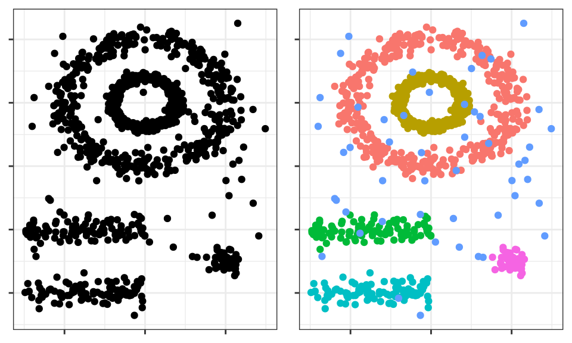

El cerebro humano identifica fácilmente 5 agrupaciones y algunas observaciones aisladas (ruido). Véanse ahora los clusters que se obtienen si se aplica, por ejemplo, *K-means clustering*.

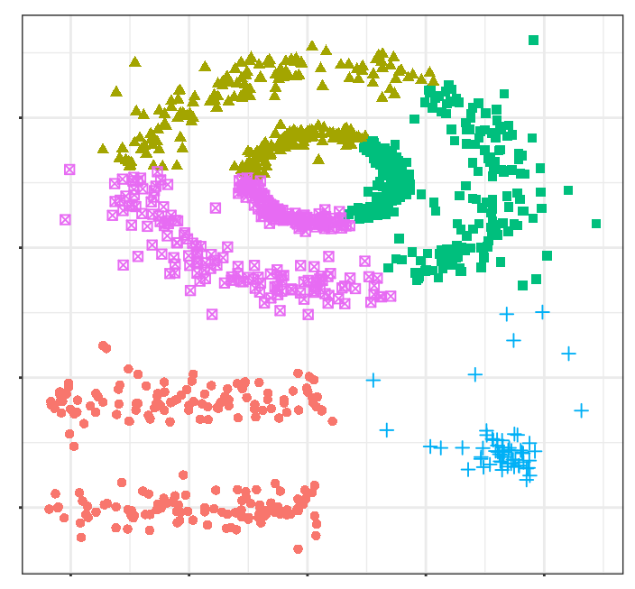

*DBSCAN* evita este problema siguiendo la idea de que, para que una observación forme parte de un *cluster*, tiene que haber un mínimo de observaciones vecinas dentro de un radio de proximidad y de que los *clusters* están separados por regiones vacías o con pocas observaciones.

El algoritmo *DBSCAN* necesita dos parámetros:

- *Epsilon* $(\epsilon)$: radio que define la región vecina a una observación, también llamada $\epsilon$-*neighborhood*.
- *Minimum points* (*min_samples*): número mínimo de observaciones dentro de la región *epsilon*.

Empleando estos dos parámetros, cada observación del set de datos se puede clasificar en una de las siguientes tres categorías:

- *Core point*: observación que tiene en su $\epsilon$-*neighborhood* un número de observaciones vecinas igual o mayor a *min_samples*.
- *Border point*: observación no satisface el mínimo de observaciones vecinas para ser *core point* pero que pertenece al $\epsilon$-*neighborhood* de otra observación que sí es *core point*.
- *Noise* u *outlier*: observación que no es *core point* ni *border point*.

Por último, empleando las tres categorías anteriores se pueden definir tres niveles de conectividad entre observaciones:

- Directamente alcanzable (*direct density reachable*): una observación $A$ es directamente alcanzable desde otra observación $B$ si $A$ forma parte del $\epsilon$-*neighborhood* de $B$ y $B$ es un *core point*. Por definición, las observaciones solo pueden ser directamente alcanzables desde un *core point*.
- Alcanzable (*density reachable*): una observación $A$ es alcanzable desde otra observación $B$ si existe una secuencia de *core points* que van desde $B$ a $A$.
- Densamente conectadas (*density conected*): dos observaciones $A$ y $B$ están densamente conectadas si existe una observación *core point* $C$ tal que $A$ y $B$ son alcanzables desde $C$.

La siguiente imagen muestra las conexiones existentes entre un conjunto de observaciones si se emplea $min_samples = 4$. La observación $A$ y el resto de observaciones marcadas en rojo son *core points*, ya que todas ellas contienen al menos 4 observaciones vecinas (incluyéndose a ellas mismas) en su $\epsilon$-*neighborhood*. Como todas son alcanzables entre ellas, forman un *cluster*. Las observaciones $B$ y $C$ no son *core points* pero son alcanzables desde $A$ a través de otros *core points*, por lo tanto, pertenecen al mismo *cluster* que $A$. La observación $N$ no es ni un *core point* ni es directamente alcanzable, por lo que se considera como ruido.

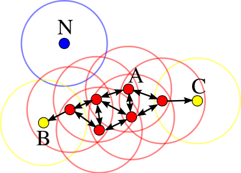

### Algoritmo

1. Para cada observación $x_i$ calcular la distancia entre ella y el resto de observaciones. Si en su $\epsilon$-*neighborhood* hay un número de observaciones $\geq min_samples$ marcar la observación como *core point*, de lo contrario marcarla como *visitada*.
2. Para cada observación $x_i$ marcada como *core point*, si todavía no ha sido asignada a ningún *cluster*, crear uno nuevo y asignarla a él. Encontrar recursivamente todas las observaciones densamente conectadas a ella y asignarlas al mismo *cluster*.
3. Iterar el mismo proceso para todas las observaciones que no hayan sido visitadas.
4. Aquellas observaciones que tras haber sido visitadas no pertenecen a ningún *cluster* se marcan como *outliers*.

Como resultado, todo *cluster* cumple dos propiedades: todos los puntos que forman parte de un mismo *cluster* están densamente conectados entre ellos y, si una observación $A$ es densamente alcanzable desde cualquier otra observación de un *cluster*, entonces $A$ también pertenece al *cluster*.

### Hiperparámetros

Como ocurre en muchas otras técnicas estadísticas, en *DBSCAN* no existe una forma única y exacta de encontrar el valor adecuado de *epsilon* $(\epsilon)$ y $min_samples$. A modo orientativo se pueden seguir las siguientes premisas:

- $min_samples$: cuanto mayor sea el tamaño del set de datos, mayor debe ser el valor mínimo de observaciones vecinas. En el libro *Practical Guide to Cluster Analysis in R* recomiendan no bajar nunca de 3. Si los datos contienen niveles altos de ruido, aumentar $min_samples$ favorecerá la creación de *clusters* significativos menos influenciados por *outliers.*
- *epsilon*: una buena forma de escoger el valor de $\epsilon$ es estudiar las distancias promedio entre las $k = min_samples$ observaciones más próximas. Al representar estas distancias en función de $\epsilon$, el punto de inflexión de la curva suele ser un valor óptimo. Si el valor de $\epsilon$ escogido es muy pequeño, una proporción alta de las observaciones no se asignarán a ningún *cluster*, por el contrario, si el valor es demasiado grande, la mayoría de observaciones se agruparán en un único *cluster*.

### Ventajas y desventajas

**Ventajas**

- No requiere que el usuario especifique el número de *clusters*.
- Es independiente de la forma que tengan los *clusters*.
- Puede identificar *outliers*, por lo que los *clusters* generados no se ven influenciados por ellos.

**Desventajas**

- Es un método determinístico siempre y cuando el orden de los datos sea el mismo. Los *border points* que son alcanzables desde más de un *cluster* pueden asignarse a uno u otro dependiendo del orden en el que se procesen los datos.
- No genera buenos resultados cuando la densidad de los grupos es muy distinta, ya que no es posible encontrar los parámetros $\epsilon$ y *min_samples* que sirvan para todos a la vez.

### Ejemplo

El set de datos `multishape` del paquete de **R** `factoextra` contiene observaciones que pertenecen a 5 grupos distintos junto con cierto ruido (*outliers*). Como se espera que la distribución espacial de los grupos no sea esférica, se aplica el método de clustering *DBSCAN*.

**Librerías**

Las librerías utilizadas en este ejemplo son:

```python
# Tratamiento de datos
# ==============================================================================
import numpy as np
import pandas as pd
from sklearn.datasets import make_blobs

# Gráficos
# ==============================================================================
import matplotlib.pyplot as plt
from matplotlib import style
style.use('ggplot') or plt.style.use('ggplot')

# Preprocesado y modelado
# ==============================================================================
from sklearn.cluster import DBSCAN
from sklearn.preprocessing import scale
from sklearn.metrics import silhouette_score

# Configuración warnings
# ==============================================================================
import warnings
warnings.filterwarnings('ignore')
```

**Datos**

```python
url = 'https://raw.githubusercontent.com/JoaquinAmatRodrigo/' \
      + 'Estadistica-machine-learning-python/master/data/multishape.csv'
datos = pd.read_csv(url)
datos.head()
```

|  | x | y | shape |
| --- | --- | --- | --- |
| 0 | -0.803739 | -0.853053 | 1 |
| 1 | 0.852851 | 0.367618 | 1 |
| 2 | 0.927180 | -0.274902 | 1 |
| 3 | -0.752626 | -0.511565 | 1 |
| 4 | 0.706846 | 0.810679 | 1 |

**Modelo**

```python
# Escalado de datos
# ==============================================================================
X = datos.drop(columns='shape').to_numpy()
X_scaled = scale(X)
```

```python
# Modelo
# ==============================================================================
modelo_dbscan = DBSCAN(
                    eps          = 0.2,
                    min_samples  = 5,
                    metric       = 'euclidean',
                )

modelo_dbscan.fit(X=X_scaled)
```

```
DBSCAN(eps=0.2)
```

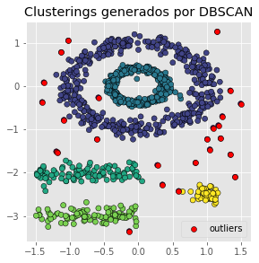

```python
# Clasificación
# ==============================================================================
labels = modelo_dbscan.labels_

fig, ax = plt.subplots(1, 1, figsize=(4.5, 4.5))

ax.scatter(
    x = X[:, 0],
    y = X[:, 1],
    c = labels,
    marker    = 'o',
    edgecolor = 'black'
)

# Los outliers se identifican con el label -1
ax.scatter(
    x = X[labels == -1, 0],
    y = X[labels == -1, 1],
    c = 'red',
    marker    = 'o',
    edgecolor = 'black',
    label = 'outliers'
)

ax.legend()
ax.set_title('Clusterings generados por DBSCAN');
```

```python
# Número de clusters y observaciones "outliers"
# ==============================================================================
n_clusters = len(set(labels)) - (1 if -1 in labels else 0)
n_noise    = list(labels).count(-1)

print(f'Número de clusters encontrados: {n_clusters}')
print(f'Número de outliers encontrados: {n_noise}')
```

```
Número de clusters encontrados: 5
Número de outliers encontrados: 25
```

## Gaussian mixture models (GMMs)

### Algoritmo

Un *Gaussian Mixture model* es un modelo probabilístico en el que se considera que las observaciones siguen una distribución probabilística formada por la combinación de múltiples distribuciones normales (componentes). En su aplicación al *clustering*, puede entenderse como una generalización de *K-means* con la que, en lugar de asignar cada observación a un único *cluster*, se obtiene una probabilidad de pertenencia a cada uno.

Para estimar los parámetros que definen la función de distribución de cada *cluster* (media y matriz de covarianza) se recurre al algoritmo de *Expectation-Maximization (EM)*. Una vez aprendidos los parámetros, se puede calcular la probabilidad que tiene cada observación de pertenecer a cada *cluster* y asignarla a aquel con mayor probabilidad.

Junto con el número de *clusters* (componentes), hay que determinar el tipo de matriz de covarianza que pueden tener los *clusters*. Dependiendo del tipo de matriz, la forma de los clusters puede ser:

- tied: todos los *clusters* comparten la misma matriz de covarianza.
- diagonal: las dimensiones de cada *cluster* a lo largo de cada dimensión puede ser distinto, pero las elipses generadas siempre quedan alineadas con los ejes, es decir, su orientaciones son limitadas.
- spherical: las dimensiones de cada *cluster* son las mismas en todas las dimensiones. Esto permite generar clusters de distinto tamaño pero todos esféricos.
- full: cada *cluster* puede puede ser modelado como una elipse cualquier orientación y dimensiones.

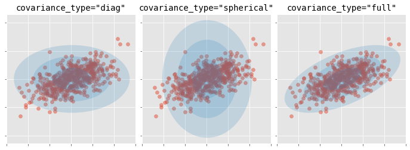

### Ejemplo

Los siguientes datos simulados contienen observaciones que pertenecen a cuatro grupos distintos. Se pretende aplicar clustering basado en un *Gaussian mixture model* con el objetivo de identificar las agrupaciones reales.

**Librerías**

Las librerías utilizadas en este ejemplo son:

```python
# Tratamiento de datos
# ==============================================================================
import numpy as np
import pandas as pd
from sklearn.datasets import make_blobs

# Gráficos
# ==============================================================================
import matplotlib.pyplot as plt
import matplotlib as mpl
from matplotlib.patches import Ellipse
from matplotlib import style
style.use('ggplot') or plt.style.use('ggplot')

# Preprocesado y modelado
# ==============================================================================
from sklearn.mixture import GaussianMixture
from sklearn.preprocessing import scale
from sklearn.metrics import silhouette_score

# Configuración warnings
# ==============================================================================
import warnings
warnings.filterwarnings('ignore')
```

**Datos**

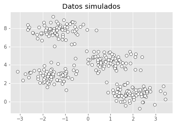

```python
# Simulación de datos
# ==============================================================================
X, y = make_blobs(
        n_samples    = 300,
        n_features   = 2,
        centers      = 4,
        cluster_std  = 0.60,
        shuffle      = True,
        random_state = 0
       )

fig, ax = plt.subplots(1, 1, figsize=(6, 3.84))
ax.scatter(
    x = X[:, 0],
    y = X[:, 1],
    c = 'white',
    marker    = 'o',
    edgecolor = 'black',
)
ax.set_title('Datos simulados');
```

**Modelo**

Con la clase `sklearn.mixture.GaussianMixture¶` de Scikit-Learn se pueden entrenar modelos de *GMMs* utilizando el algoritmo *expectation-maximization (EM)* . Entre sus parámetros destacan:

- `n_components`: número de componentes (en este caso *clusters*) que forman el modelo.
- `covariance_type`: tipo de matriz de covarianza (‘full’ (default), ‘tied’, ‘diag’, ‘spherical’).
- `max_iter`: número máximo de iteraciones permitidas.
- `random_state`: semilla para garantizar la reproducibilidad de los resultados.

```python
# Modelo
# ==============================================================================
modelo_gmm = GaussianMixture(n_components=4, covariance_type='full', random_state=123)
modelo_gmm.fit(X=X)
```

```
GaussianMixture(n_components=4, random_state=123)
```

El objeto devuelto por `GaussianMixture` contiene entre otros datos: el peso de cada componente (*cluster*) en el modelo (`weights_`), su media (`means_`) y matriz de covarianza (`covariances_`).La estructura de esta última depende del tipo de matriz empleada en el ajuste del modelo (`covariance_type`).

```python
# Media de cada componente
modelo_gmm.means_
```

```
array([[ 1.98299679,  0.86735608],
       [-1.37355181,  7.75436785],
       [ 0.93842466,  4.41564635],
       [-1.58913964,  2.82465347]])
```

```python
# Matriz de covarianza de cada componente
modelo_gmm.covariances_
```

```
array([[[ 0.33998651, -0.02620931],
        [-0.02620931,  0.34588507]],

       [[ 0.41216925,  0.02884065],
        [ 0.02884065,  0.37959193]],

       [[ 0.3808649 , -0.02231979],
        [-0.02231979,  0.34881473]],

       [[ 0.32360185,  0.01027908],
        [ 0.01027908,  0.30862196]]])
```

**Predicción y clasificación**

Una vez entrenado el modelo *GMMs*, se puede predecir la probabilidad que tiene cada observación de pertenecer a cada una de las componentes (*clusters*). Para obtener la clasificación final, se asigna a la componente con mayor probabilidad.

```python
# Probabilidades
# ==============================================================================
# Cada fila es una observación y cada columna la probabilidad de pertenecer a
# cada una de las componentes.
probabilidades = modelo_gmm.predict_proba(X)
probabilidades
```

```
array([[9.71688955e-01, 8.04672295e-21, 2.59296402e-02, 2.38140471e-03],
       [7.13116691e-33, 9.99999993e-01, 7.15846263e-09, 2.34837535e-15],
       [8.78022033e-12, 2.04767765e-08, 9.99999970e-01, 9.13480329e-09],
       ...,
       [4.92339895e-10, 8.75462809e-09, 9.99965893e-01, 3.40976171e-05],
       [6.44915198e-30, 9.99996988e-01, 3.01241053e-06, 1.52780115e-18],
       [1.99754828e-11, 4.05180546e-15, 4.39280339e-07, 9.99999561e-01]])
```

```python
# Clasificación (asignación a la componente de mayor probabilidad)
# ==============================================================================
# Cada fila es una observación y cada columna la probabilidad de pertenecer a
# cada una de las componentes.
clasificacion = modelo_gmm.predict(X)
clasificacion
```

```
array([0, 1, 2, 1, 0, 0, 3, 2, 1, 1, 3, 1, 2, 1, 0, 2, 2, 0, 3, 3, 0, 0,
       2, 3, 3, 2, 0, 2, 3, 2, 1, 1, 2, 1, 1, 1, 1, 1, 3, 0, 2, 3, 2, 2,
       3, 3, 1, 3, 1, 0, 3, 0, 1, 0, 0, 3, 1, 3, 1, 0, 1, 2, 1, 3, 3, 3,
       1, 0, 1, 3, 2, 3, 1, 3, 3, 1, 3, 2, 0, 1, 0, 2, 0, 0, 1, 2, 0, 2,
       1, 1, 2, 0, 1, 3, 3, 2, 0, 0, 2, 3, 1, 0, 1, 0, 2, 0, 0, 2, 1, 2,
       3, 3, 0, 1, 0, 2, 1, 0, 0, 2, 3, 0, 3, 0, 0, 0, 0, 3, 0, 3, 1, 3,
       3, 0, 1, 3, 3, 1, 2, 1, 1, 3, 2, 3, 2, 3, 1, 2, 1, 1, 1, 2, 1, 2,
       0, 3, 1, 3, 0, 2, 1, 2, 2, 0, 2, 3, 3, 2, 0, 2, 2, 1, 0, 2, 3, 1,
       0, 0, 2, 3, 0, 2, 3, 3, 2, 2, 2, 2, 0, 1, 2, 3, 2, 2, 3, 3, 3, 2,
       3, 1, 2, 3, 0, 3, 2, 1, 3, 1, 2, 1, 2, 3, 2, 2, 1, 3, 3, 0, 0, 2,
       1, 0, 0, 3, 0, 3, 2, 1, 1, 2, 2, 1, 2, 0, 3, 2, 0, 3, 1, 3, 0, 2,
       0, 1, 1, 1, 1, 3, 3, 1, 2, 3, 0, 2, 3, 3, 3, 0, 0, 1, 2, 2, 3, 0,
       1, 3, 2, 1, 2, 0, 0, 3, 3, 2, 0, 0, 0, 2, 1, 1, 0, 0, 2, 0, 0, 0,
       1, 3, 1, 2, 0, 0, 1, 1, 1, 0, 0, 2, 1, 3])
```

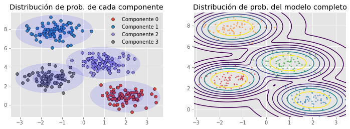

```python
# Representación gráfica
# ==============================================================================
# Codigo obtenido de:
# https://github.com/amueller/COMS4995-s20/tree/master/slides/aml-14-clustering-mixture-models
def make_ellipses(gmm, ax):
    for n in range(gmm.n_components):
        if gmm.covariance_type == 'full':
            covariances = gmm.covariances_[n]
        elif gmm.covariance_type == 'tied':
            covariances = gmm.covariances_
        elif gmm.covariance_type == 'diag':
            covariances = np.diag(gmm.covariances_[n])
        elif gmm.covariance_type == 'spherical':
            covariances = np.eye(gmm.means_.shape[1]) * gmm.covariances_[n]
        v, w = np.linalg.eigh(covariances)
        u = w[0] / np.linalg.norm(w[0])
        angle = np.arctan2(u[1], u[0])
        angle = 180 * angle / np.pi  # convert to degrees
        v = 2. * np.sqrt(2.) * np.sqrt(v)

        for i in range(1,3):
            ell = mpl.patches.Ellipse(gmm.means_[n], i*v[0], i*v[1],
                                      180 + angle, color="blue")
            ell.set_clip_box(ax.bbox)
            ell.set_alpha(0.1)
            ax.add_artist(ell)


fig, axs = plt.subplots(1, 2, figsize=(12, 3.84))

# Distribución de probabilidad de cada componente
for i in np.unique(clasificacion):
    axs[0].scatter(
        x = X[clasificacion == i, 0],
        y = X[clasificacion == i, 1],
        c = plt.rcParams['axes.prop_cycle'].by_key()['color'][i],
        marker    = 'o',
        edgecolor = 'black',
        label= f"Componente {i}"
    )

make_ellipses(modelo_gmm, ax = axs[0])
axs[0].set_title('Distribución de prob. de cada componente')
axs[0].legend()

# Distribución de probabilidad del modelo completo
xs = np.linspace(min(X[:, 0]), max(X[:, 0]), 1000)
ys = np.linspace(min(X[:, 1]), max(X[:, 1]), 1000)
xx, yy = np.meshgrid(xs, ys)
scores = modelo_gmm.score_samples(np.c_[xx.ravel(), yy.ravel()], )
axs[1].scatter(X[:, 0], X[:, 1], s=5, alpha=.6, c=plt.cm.tab10(clasificacion))
scores = np.exp(scores) # Las probabilidades están en log
axs[1].contour(
    xx, yy, scores.reshape(xx.shape),
    levels=np.percentile(scores, np.linspace(0, 100, 10))[1:-1]
)
axs[1].set_title('Distribución de prob. del modelo completo');
```

**Número de clusters**

Dado que los modelos GMM son modelos probabilísticos, se puede recurrir a métricas como el *Akaike information criterion (AIC)* o *Bayesian information criterion (BIC)* para identificar cómo de bien se ajustan los datos observados a modelo creado.

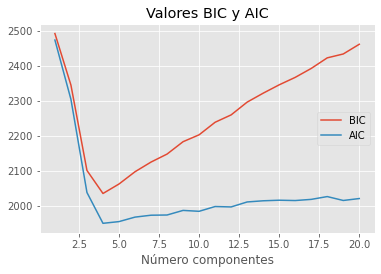

```python
n_components = range(1, 21)
valores_bic = []
valores_aic = []

for i in n_components:
    modelo = GaussianMixture(n_components=i, covariance_type="full")
    modelo = modelo.fit(X)
    valores_bic.append(modelo.bic(X))
    valores_aic.append(modelo.aic(X))

fig, ax = plt.subplots(1, 1, figsize=(6, 3.84))
ax.plot(n_components, valores_bic, label='BIC')
ax.plot(n_components, valores_aic, label='AIC')
ax.set_title("Valores BIC y AIC")
ax.set_xlabel("Número componentes")
ax.legend();
```

```python
print(f"Número óptimo acorde al BIC: {range(1, 21)[np.argmin(valores_bic)]}")
print(f"Número óptimo acorde al AIC: {range(1, 21)[np.argmin(valores_aic)]}")
```

```
Número óptimo acorde al BIC: 4
Número óptimo acorde al AIC: 4
```

Ambas métricas identifican el 4 como número óptimo de *clusters* (componentes).

## Limitaciones del clustering

El *clustering* puede ser una herramienta muy útil para encontrar agrupaciones en los datos, sobre todo a medida que el volumen de los mismos aumenta. Sin embargo, es importante recordar sus limitaciones o problemas que pueden surgir al aplicarlo. Algunas de ellas son:

- Pequeñas decisiones pueden tener grandes consecuencias:a la hora de utilizar los métodos de *clustering* se tienen que tomar decisiones que influyen en gran medida en los resultados obtenidos. No existe una única respuesta correcta, por lo que en la práctica se prueban diferentes opciones.
  - Escalado y centrado de las variables
  - Qué medida de distancia/similitud emplear
  - Número de *clusters*
  - Tipo de *linkage* empleado en *hierarchical clustering*
  - A que altura establecer el corte de un dendrograma
- Validación de los clusters obtenidos: no es fácil comprobar la validez de los resultados ya que en la mayoría de escenarios se desconoce la verdadera agrupación.
- Falta de robustez: los métodos de *K-means-clustering* e *hierarchical clustering* asignan obligatoriamente cada observación a un grupo. Si existe en la muestra algún *outlier*, a pesar de que realmente no pertenezca a ningún grupo, el algoritmo lo asignará a uno de ellos provocando una distorsión significativa del *cluster* en cuestión. Algunas alternativas son *k-medoids* y *DBSCAN*.
- La naturaleza del algoritmo de *hierarchical clustering* conlleva que, si se realiza una mala división en los pasos iniciales, no se pueda corregir en los pasos siguientes.

## Información de sesión

```python
from sinfo import sinfo
sinfo()
```

```
-----
ipykernel   5.3.4
matplotlib  3.3.2
numpy       1.19.2
pandas      1.1.3
scipy       1.5.2
sinfo       0.3.1
sklearn     0.23.2
statsmodels 0.12.1
-----
IPython             7.18.1
jupyter_client      6.1.7
jupyter_core        4.6.3
jupyterlab          2.2.9
notebook            6.1.4
-----
Python 3.7.9 (default, Aug 31 2020, 12:42:55) [GCC 7.3.0]
Linux-5.4.0-1032-aws-x86_64-with-debian-buster-sid
4 logical CPU cores, x86_64
-----
Session information updated at 2020-12-18 20:32
```

## Bibliografía

Introduction to Machine Learning with Python: A Guide for Data Scientists

Python Data Science Handbook by Jake VanderPlas

Linear Models with R by Julian J.Faraway

An Introduction to Statistical Learning: with Applications in R (Springer Texts in Statistics)

Points of Significance Clustering by Naomi Altman & Martin Krzywinski

**¿Cómo citar este documento?**

Clustering con Python por Joaquín Amat Rodrigo, disponible con licencia CC BY-NC-SA 4.0 en https://www.cienciadedatos.net/documentos/py20-clustering-con-python.html

**¿Te ha gustado el artículo? Tu ayuda es importante**

Mantener un sitio web tiene unos costes elevados, tu contribución me ayudará a seguir generando contenido divulgativo gratuito. ¡Muchísimas gracias! 😊

Este contenido, creado por Joaquín Amat Rodrigo, tiene licencia [Attribution-NonCommercial-ShareAlike 4.0 International](https://creativecommons.org/licenses/by-nc-sa/4.0/).

Se permite:

- Compartir: copiar y redistribuir el material en cualquier medio o formato.
- Adaptar: remezclar, transformar y crear a partir del material.

Bajo los siguientes términos:

- Atribución: Debes otorgar [el crédito adecuado](https://creativecommons.org/licenses/by-nc-sa/4.0/deed.es#ref-appropriate-credit), proporcionar un enlace a la licencia e [indicar si se realizaron cambios](https://creativecommons.org/licenses/by-nc-sa/4.0/deed.es#ref-indicate-changes). Puedes hacerlo de cualquier manera razonable, pero no de una forma que sugiera que el licenciante te respalda o respalda tu uso.
- NoComercial: No puedes utilizar el material para [fines comerciales](https://creativecommons.org/licenses/by-nc-sa/4.0/deed.es#ref-commercial-purposes).
- CompartirIgual: Si remezclas, transformas o creas a partir del material, debes distribuir tus contribuciones bajo la [misma licencia](https://creativecommons.org/licenses/by-nc-sa/4.0/deed.es#ref-same-license) que el original.